# ▒ 앙상블 ▒

## 0. 환경설정

```python
import pandas as pd
import numpy as np
import os
from functools import reduce
from sklearn.metrics import confusion_matrix
import matplotlib.pyplot as plt

# 시드 설정
np.random.seed(0)
```

## 1. 데이터 불러오기

**[데이터 다운로드]**

- C드라이브에 [Python_project] 생성
- [Python_project] 하위폴더로 [DAT] 폴더 생성
- 데이터 스토어에서 샘플데이터(3.아파트_주소기반_주택지역특성시세정보_DB.xlsx)를 "C:/python_project/DAT/"에 다운로드  
  (https://www.datastore.or.kr/file/detail?id=2c0a9616-4d78-403c-9d77-3db2effb2a74&page=1&viewCount=10&sort=1&order=1&source=1&keyword=%EC%95%84%ED%8C%8C%ED%8A%B8)
- 서울/수도권 및 5대광역시 아파트에 대한 주소테이블 외 4개의 테이블(정보집단)로 구성되며 각각 주택특성정보, 지역특성정보, 가격/신뢰등급/예상회수율정보 테이블로 이루어져 있고, 각 테이블간은 고유키값(NUM)으로 연계되어 있음

**[데이터 호출]**

```python
dirFolder = 'C:/Users/Admin/Begas_Edu_Finacial_Preprocess/python_project/dat'
fileName = '3.아파트_주소기반_주택지역특성시세정보_DB.xlsx'

DF1 =pd.read_excel(os.path.join(dirFolder, fileName), sheet_name = 0)
DF2 =pd.read_excel(os.path.join(dirFolder, fileName), sheet_name = 1)
DF3 =pd.read_excel(os.path.join(dirFolder, fileName), sheet_name = 2)
DF4 =pd.read_excel(os.path.join(dirFolder, fileName), sheet_name = 3)

DF = reduce(lambda x,y: pd.merge(x,y) , [DF1, DF2, DF3, DF4])
DF['LAND_ACCESS'] = DF['LAND_ACCESS'].astype('float64')
selectColumns = ["SGG","PRICE_GEN", "FLOOR","PRIV_AREA", "PUB_AREA",
                 "SUM_AREA","UNIT_NUM","PARK_NUM", "LAND_ACCESS", "SUB_DIST"]
DF = DF[selectColumns].dropna(axis = 0)
print(DF.shape)
DF.head()
```

```
(492, 10)
```

|  | SGG | PRICE_GEN | FLOOR | PRIV_AREA | PUB_AREA | SUM_AREA | UNIT_NUM | PARK_NUM | LAND_ACCESS | SUB_DIST |
| --- | --- | --- | --- | --- | --- | --- | --- | --- | --- | --- |
| 0 | 종로구 | 124000 | 14 | 126.34 | 88.60 | 214.94 | 1011.0 | 1480 | 8920000.0 | 501 |
| 1 | 종로구 | 131000 | 2 | 147.31 | 103.30 | 250.61 | 1011.0 | 1480 | 8920000.0 | 501 |
| 2 | 종로구 | 107000 | 14 | 94.51 | 66.27 | 160.78 | 1011.0 | 1480 | 8920000.0 | 501 |
| 3 | 종로구 | 70600 | 7 | 105.07 | 13.68 | 118.75 | 72.0 | 0 | 19000000.0 | 295 |
| 4 | 종로구 | 131000 | 6 | 140.78 | 100.84 | 241.62 | 462.0 | 0 | 14500000.0 | 422 |

- SGG : 시군구
- PRICE_GEN ; 일반거래시세
- FLOOR : 층명
- PRIV_AREA : 전유면적
- PUB_AREA : 공유면적
- SUM_AREA : 계약 면적
- UNIT_NUM : 총세대수
- PARK_NUM : 총주차대수
- LAND_ACCESS : 개별공시지가
- SUB_DIST : 지하철역과의 거리

**[데이터 가공]** 데이터가 적은 지역 전처리(광진구 제거, 종로구와 중구 통합)

```python
preDF = DF.loc[DF['SGG'] != '광진구']
preDF = preDF.reset_index(drop = True)
preDF.loc[preDF['SGG'] == '성동구', 'SGG'] = 'A'
preDF.loc[preDF['SGG'] == '용산구', 'SGG'] = 'B'
preDF.loc[preDF['SGG'] == '종로구', 'SGG'] = 'C'
preDF.loc[preDF['SGG'] == '중구', 'SGG'] = 'C'
preDF.SGG.value_counts()
```

```
A    224
C    124
B    115
Name: SGG, dtype: int64
```

```python
preDF.head()
```

|  | SGG | PRICE_GEN | FLOOR | PRIV_AREA | PUB_AREA | SUM_AREA | UNIT_NUM | PARK_NUM | LAND_ACCESS | SUB_DIST |
| --- | --- | --- | --- | --- | --- | --- | --- | --- | --- | --- |
| 0 | C | 124000 | 14 | 126.34 | 88.60 | 214.94 | 1011.0 | 1480 | 8920000.0 | 501 |
| 1 | C | 131000 | 2 | 147.31 | 103.30 | 250.61 | 1011.0 | 1480 | 8920000.0 | 501 |
| 2 | C | 107000 | 14 | 94.51 | 66.27 | 160.78 | 1011.0 | 1480 | 8920000.0 | 501 |
| 3 | C | 70600 | 7 | 105.07 | 13.68 | 118.75 | 72.0 | 0 | 19000000.0 | 295 |
| 4 | C | 131000 | 6 | 140.78 | 100.84 | 241.62 | 462.0 | 0 | 14500000.0 | 422 |

**[데이터 분할]** Training set 70%, Test set 30% 무작위 추출을 이용하여 나누기

```python
rowNum = preDF.shape[0] # 행의 수
trainIdx = np.random.choice(rowNum, int(rowNum*0.7), replace = False).tolist()
testIdx  = [idx for idx in range(preDF.shape[0]) if idx not in trainIdx ]
```

```python
xColL = ['PRICE_GEN', 'FLOOR', 'PRIV_AREA', 'PUB_AREA', 'SUM_AREA',
       'UNIT_NUM', 'PARK_NUM', 'LAND_ACCESS', 'SUB_DIST']
```

```python
xTrain = preDF.loc[trainIdx, xColL].to_numpy()
xTest  = preDF.loc[testIdx, xColL].to_numpy()
yTrain = preDF.loc[trainIdx, 'SGG'].to_numpy()
yTest  = preDF.loc[testIdx, 'SGG'].to_numpy()
```

```python
print('훈련 데이터 차원 :', xTrain.shape, yTrain.shape)
print('테스트 데이터 차원 :', xTest.shape, yTest.shape)
```

```
훈련 데이터 차원 : (324, 9) (324,)
테스트 데이터 차원 : (139, 9) (139,)
```

## 2. 앙상블

### 2.1 Bagging

**[모형적합]** nbagg : bootstrap의 개수 (bootstrap의 개수는 충분히 크게 하는것이 좋다.)

```python
from sklearn.tree import DecisionTreeClassifier
from sklearn.ensemble import BaggingClassifier
tree = DecisionTreeClassifier()
bag_model = BaggingClassifier(tree, n_estimators=100, max_samples=0.8,
                        random_state=1)
```

```python
bag_model.fit(xTrain, yTrain)
```

```
BaggingClassifier(base_estimator=DecisionTreeClassifier(ccp_alpha=0.0,
                                                        class_weight=None,
                                                        criterion='gini',
                                                        max_depth=None,
                                                        max_features=None,
                                                        max_leaf_nodes=None,
                                                        min_impurity_decrease=0.0,
                                                        min_impurity_split=None,
                                                        min_samples_leaf=1,
                                                        min_samples_split=2,
                                                        min_weight_fraction_leaf=0.0,
                                                        presort='deprecated',
                                                        random_state=None,
                                                        splitter='best'),
                  bootstrap=True, bootstrap_features=False, max_features=1.0,
                  max_samples=0.8, n_estimators=100, n_jobs=None,
                  oob_score=False, random_state=1, verbose=0, warm_start=False)
```

```python
# 테스트 실제값
yTest
```

```
array(['C', 'C', 'C', 'C', 'C', 'C', 'C', 'C', 'C', 'C', 'C', 'C', 'C',
       'C', 'C', 'C', 'C', 'C', 'C', 'C', 'C', 'C', 'C', 'C', 'C', 'C',
       'C', 'C', 'C', 'C', 'C', 'C', 'C', 'C', 'C', 'C', 'C', 'C', 'C',
       'C', 'B', 'B', 'B', 'B', 'B', 'B', 'B', 'B', 'B', 'B', 'B', 'B',
       'B', 'B', 'B', 'B', 'B', 'B', 'B', 'B', 'B', 'B', 'B', 'B', 'B',
       'B', 'B', 'B', 'B', 'B', 'B', 'A', 'A', 'A', 'A', 'A', 'A', 'A',
       'A', 'A', 'A', 'A', 'A', 'A', 'A', 'A', 'A', 'A', 'A', 'A', 'A',
       'A', 'A', 'A', 'A', 'A', 'A', 'A', 'A', 'A', 'A', 'A', 'A', 'A',
       'A', 'A', 'A', 'A', 'A', 'A', 'A', 'A', 'A', 'A', 'A', 'A', 'A',
       'A', 'A', 'A', 'A', 'A', 'A', 'A', 'A', 'A', 'A', 'A', 'A', 'A',
       'A', 'A', 'A', 'A', 'A', 'A', 'A', 'A', 'A'], dtype=object)
```

```python
yPred = bag_model.predict(xTest)
yPred
```

```
array(['C', 'C', 'C', 'C', 'C', 'C', 'C', 'C', 'A', 'C', 'C', 'C', 'A',
       'A', 'C', 'C', 'C', 'C', 'C', 'C', 'C', 'C', 'C', 'C', 'C', 'C',
       'C', 'C', 'C', 'C', 'C', 'C', 'C', 'C', 'A', 'C', 'C', 'C', 'C',
       'A', 'B', 'B', 'B', 'B', 'B', 'B', 'B', 'C', 'B', 'B', 'B', 'B',
       'B', 'B', 'B', 'B', 'B', 'B', 'B', 'B', 'B', 'B', 'B', 'B', 'B',
       'B', 'B', 'B', 'B', 'B', 'B', 'A', 'A', 'A', 'A', 'A', 'A', 'A',
       'A', 'A', 'A', 'A', 'A', 'A', 'C', 'A', 'A', 'A', 'A', 'A', 'A',
       'A', 'A', 'A', 'A', 'A', 'A', 'A', 'A', 'A', 'A', 'A', 'A', 'A',
       'A', 'A', 'A', 'A', 'A', 'A', 'A', 'A', 'A', 'A', 'A', 'A', 'C',
       'C', 'A', 'A', 'A', 'A', 'A', 'A', 'A', 'A', 'A', 'A', 'A', 'A',
       'A', 'A', 'A', 'A', 'B', 'A', 'A', 'A', 'B'], dtype=object)
```

**[예측]** 그룹예측

```python
confusionMatrix = confusion_matrix(yTest, yPred)
confusionMatrix
```

```
array([[63,  2,  3],
       [ 0, 30,  1],
       [ 5,  0, 35]], dtype=int64)
```

**[결과]** 오분류율

```python
print('오분류율 : ', round(np.mean(yTest != yPred)*100, 4), '%'  )
```

```
오분류율 :  7.9137 %
```

**[예측]** 확률예측

```python
yPred = bag_model.predict_proba(xTest)
yPred[:6]
```

```
array([[0.01, 0.44, 0.55],
       [0.03, 0.28, 0.69],
       [0.02, 0.06, 0.92],
       [0.39, 0.  , 0.61],
       [0.21, 0.  , 0.79],
       [0.19, 0.  , 0.81]])
```

### 2.2 Boosting : gbm(gradient boosting model)

```python
from sklearn.ensemble import GradientBoostingClassifier
gbm_model = GradientBoostingClassifier(random_state=0)
gbm_model.fit(xTrain, yTrain)
```

```
GradientBoostingClassifier(ccp_alpha=0.0, criterion='friedman_mse', init=None,
                           learning_rate=0.1, loss='deviance', max_depth=3,
                           max_features=None, max_leaf_nodes=None,
                           min_impurity_decrease=0.0, min_impurity_split=None,
                           min_samples_leaf=1, min_samples_split=2,
                           min_weight_fraction_leaf=0.0, n_estimators=100,
                           n_iter_no_change=None, presort='deprecated',
                           random_state=0, subsample=1.0, tol=0.0001,
                           validation_fraction=0.1, verbose=0,
                           warm_start=False)
```

**[예측]** 그룹예측

```python
yPred = gbm_model.predict(xTest)
```

```python
confusionMatrix = confusion_matrix(yTest, yPred)
confusionMatrix
```

```
array([[65,  1,  2],
       [ 0, 30,  1],
       [ 4,  0, 36]], dtype=int64)
```

**[결과]** 오분류율

```python
print('오분류율 : ', round(np.mean(yTest != yPred)*100, 4), '%'  )
```

```
오분류율 :  5.7554 %
```

**[예측]** 확률예측

```python
yProbPred = gbm_model.predict_proba(xTest)
yProbPred[:6]
```

```
array([[8.35623214e-03, 8.68440515e-02, 9.04799716e-01],
       [1.02960347e-03, 2.59502336e-02, 9.73020163e-01],
       [1.88305630e-03, 9.81478276e-03, 9.88302161e-01],
       [2.87881781e-01, 1.63325889e-03, 7.10484960e-01],
       [3.65577587e-02, 7.78564060e-04, 9.62663677e-01],
       [2.99633509e-02, 5.63364139e-04, 9.69473285e-01]])
```

**[Boosting 횟수 M 정하기]**

**n_estimators argument**는 앙상블에 추가할 트리 수입니다.

```python
mNum = [10, 100, 200, 300, 400]

errorRateL = []
for M in mNum:
    clf = GradientBoostingClassifier(n_estimators = M,
                                     learning_rate = 0.05,
                                     min_samples_leaf = 3,
                                     random_state=0).fit(xTrain,yTrain)
    yPred = clf.predict(xTest)
    errorRate = round(np.mean(yTest != yPred)*100, 10)
    errorRateL.append(errorRate)
```

```python
errorRateL
```

```
[16.5467625899, 10.071942446, 7.9136690647, 6.4748201439, 7.9136690647]
```

### 2.3 Random Forest

**[모형적합]**

```python
from sklearn.tree import DecisionTreeClassifier
from sklearn.ensemble import RandomForestClassifier

rf_Model = RandomForestClassifier(n_estimators = 1000,
                                  max_features = 3,
                                  min_samples_leaf = 3).fit(xTrain, yTrain)
rf_Model
```

```
RandomForestClassifier(bootstrap=True, ccp_alpha=0.0, class_weight=None,
                       criterion='gini', max_depth=None, max_features=3,
                       max_leaf_nodes=None, max_samples=None,
                       min_impurity_decrease=0.0, min_impurity_split=None,
                       min_samples_leaf=3, min_samples_split=2,
                       min_weight_fraction_leaf=0.0, n_estimators=1000,
                       n_jobs=None, oob_score=False, random_state=None,
                       verbose=0, warm_start=False)
```

**[예측]**

```python
yPred = rf_Model.predict(xTest)
yPred # 테스트 예측값
```

```
array(['B', 'C', 'C', 'C', 'C', 'C', 'A', 'C', 'A', 'C', 'C', 'A', 'A',
       'A', 'C', 'A', 'C', 'C', 'C', 'C', 'C', 'C', 'C', 'C', 'C', 'C',
       'C', 'C', 'C', 'C', 'C', 'C', 'C', 'C', 'A', 'C', 'C', 'C', 'C',
       'A', 'B', 'C', 'B', 'B', 'B', 'B', 'B', 'B', 'B', 'A', 'B', 'B',
       'B', 'B', 'B', 'B', 'B', 'B', 'B', 'B', 'B', 'B', 'B', 'B', 'B',
       'B', 'B', 'B', 'B', 'B', 'B', 'A', 'A', 'A', 'A', 'A', 'A', 'A',
       'A', 'A', 'A', 'A', 'A', 'A', 'C', 'A', 'A', 'A', 'A', 'A', 'A',
       'A', 'A', 'A', 'A', 'A', 'A', 'A', 'A', 'A', 'A', 'A', 'A', 'A',
       'A', 'A', 'A', 'A', 'A', 'A', 'A', 'A', 'A', 'A', 'A', 'A', 'B',
       'A', 'A', 'A', 'A', 'A', 'A', 'A', 'A', 'A', 'A', 'A', 'A', 'A',
       'A', 'A', 'A', 'A', 'B', 'A', 'A', 'A', 'B'], dtype=object)
```

```python
confusionMatrix = confusion_matrix(yTest, yPred)
confusionMatrix
```

```
array([[64,  3,  1],
       [ 1, 29,  1],
       [ 8,  1, 31]], dtype=int64)
```

**[결과]** 오분류율

```python
print('오분류율 : ', round(np.mean(yTest != yPred)*100, 4), '%'  )
```

```
오분류율 :  10.7914 %
```

**[Random Forest 에서 k 정하기]**

**max_features argument**는 각 트리에 사용할 feature 수입니다.

```python
errorRateL = []
for fNum in range(2, xTrain.shape[1]):
    print(fNum ,end = '>>')
    rf_Model = RandomForestClassifier(random_state = 0,
                                      n_estimators = 1000,
                                      max_features = fNum,
                                      min_samples_leaf = 2).fit(xTrain, yTrain)
    yPred = rf_Model.predict(xTest)
    errorRate = round(np.mean(yTest != yPred), 10)
    errorRateL.append(errorRate)
```

```
2>>3>>4>>5>>6>>7>>8>>
```

```python
errorRateL
```

```
[0.1079136691,
 0.071942446,
 0.0863309353,
 0.071942446,
 0.0863309353,
 0.0935251799,
 0.0935251799]
```

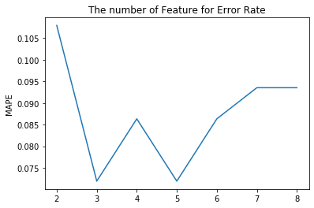

```python
plt.plot(range(2,xTrain.shape[1]), errorRateL)
plt.title('The number of Feature for Error Rate')
plt.show
plt.ylabel('MAPE')
plt.show()
```